# Part2.r

Ryo Nakagawara

Mon Oct 09 17:39:31 2017

As always let’s load the various packages we are going to be using!

```r
# Packages:
library(tidyverse)  # for dplyr, tidyr, ggplot2
library(tidytext)   # for separating text into words with unnest_tokens() function
library(stringr)    # for string detection, extraction, manipulation, etc.

library(gplots)     # for a certain type of plots not in ggplot2
library(ggrepel)    # for making sure labels don't overlap
library(scales)     # for fixing and tweaking the scales on graphs
library(gridExtra)  # for arranging multiple plots into a single page
```

- how accurate are the numLines and numWord counts?
- comparison when unnest lyrics by line and word in later section of this article!

```r
# Lyrics analysis ---------------------------------------------------------

df <- df %>%
  mutate(numLines = str_count(lyrics, '<br>') + 1,       # num of lines per song
         numWord = str_count(lyrics, ' ') + 1)           # num of words per song
```

```r
wordToken <-  df %>%
  unnest_tokens(line, lyrics, token = stringr::str_split, pattern = ' <br>') %>%
  unnest_tokens(word, line) %>%
  mutate(wordCount = row_number()) %>%    # count of words in order of line, song, album
  select(-numLines, -numWord)
  # take out numLines and numWord, can calculate independtly later

glimpse(wordToken)
```

```
## Observations: 18,757
## Variables: 10
## $ ID        <int> 1, 1, 1, 1, 1, 1, 1, 1, 1, 1, 1, 1, 1, 1, 1, 1, 1, 1...
## $ album     <fctr> Identity Crisis, Identity Crisis, Identity Crisis, ...
## $ year      <int> 2000, 2000, 2000, 2000, 2000, 2000, 2000, 2000, 2000...
## $ tracknum  <int> 1, 1, 1, 1, 1, 1, 1, 1, 1, 1, 1, 1, 1, 1, 1, 1, 1, 1...
## $ title     <chr> "Identity Crisis", "Identity Crisis", "Identity Cris...
## $ writers   <chr> "Dustin Kensrue", "Dustin Kensrue", "Dustin Kensrue"...
## $ length    <S4: Period> 2M 58S, 2M 58S, 2M 58S, 2M 58S, 2M 58S, 2M 58...
## $ lengthS   <S4: Period> 178S, 178S, 178S, 178S, 178S, 178S, 178S, 178...
## $ word      <chr> "image", "marred", "by", "self", "infliction", "priv...
## $ wordCount <int> 1, 2, 3, 4, 5, 6, 7, 8, 9, 10, 11, 12, 13, 14, 15, 1...
```

```r
# uncleaned unigrams containing all 'stop words' such as 'I', 'you', 'we', 'very', etc. etc.
```

Now let’s count the how many times each word appears throughout the lyrics!

```r
countWord <- wordToken %>% count(word, sort=TRUE)
countWord  %>% head(10)
```

```
## # A tibble: 10 x 2
##     word     n
##    <chr> <int>
##  1   the   864
##  2   and   609
##  3     i   582
##  4    to   400
##  5   you   373
##  6    we   335
##  7     a   333
##  8    of   296
##  9    in   273
## 10    my   251
```

```r
# 'the' is most common....
```

What are stop words? Stop words are… and in the `tidytext` package they are populated from the “onix”, “SMART”, and “snowball” lexicons. For more information see here!

```r
# Include stop_words ------------------------------------------------------

data("stop_words")
stop_words         # data base of "stop words" to clean unigrams.
```

```
## # A tibble: 1,149 x 2
##           word lexicon
##          <chr>   <chr>
##  1           a   SMART
##  2         a's   SMART
##  3        able   SMART
##  4       about   SMART
##  5       above   SMART
##  6   according   SMART
##  7 accordingly   SMART
##  8      across   SMART
##  9    actually   SMART
## 10       after   SMART
## # ... with 1,139 more rows
```

```r
set.seed(1)
sample_stop <- stop_words %>% sample_n(10)

sample_stop
```

```
## # A tibble: 10 x 2
##       word  lexicon
##      <chr>    <chr>
##  1   noone    SMART
##  2   thank    SMART
##  3  hadn't snowball
##  4 several     onix
##  5    into    SMART
##  6    said     onix
##  7   think     onix
##  8   alone     onix
##  9    then snowball
## 10    best    SMART
```

Now we can create a new dataset where we filter out the “stop words”" from our `word` column in `wordToken`.

This can be done by using anti_join() function which returns all rows from `x` (our original `wordtoken` dataset) where there are no matching values in `y` (`stop_words` dataset) on a variable with a common name across both datasets (`word`).

to use the stop words in the stop_words dataset to filter out any matching words in the “word” column of our unnested dataset that we had just created.

```r
wordToken2 <- wordToken %>%
  anti_join(stop_words) %>% # Take out rows of `words` in wordToken that appear in stop_words
  select(-wordCount) %>%    # Won't need wordCount
  arrange(ID)               # Or by track_num, essentially the same thing

countWord2 <- wordToken2 %>% count(word, sort=TRUE)

countWord2 %>% head(10)
```

```
## # A tibble: 10 x 2
##     word     n
##    <chr> <int>
##  1  eyes    73
##  2  love    64
##  3 light    53
##  4 blood    43
##  5  life    43
##  6  fall    37
##  7 world    35
##  8  time    32
##  9 heart    31
## 10  hold    30
```

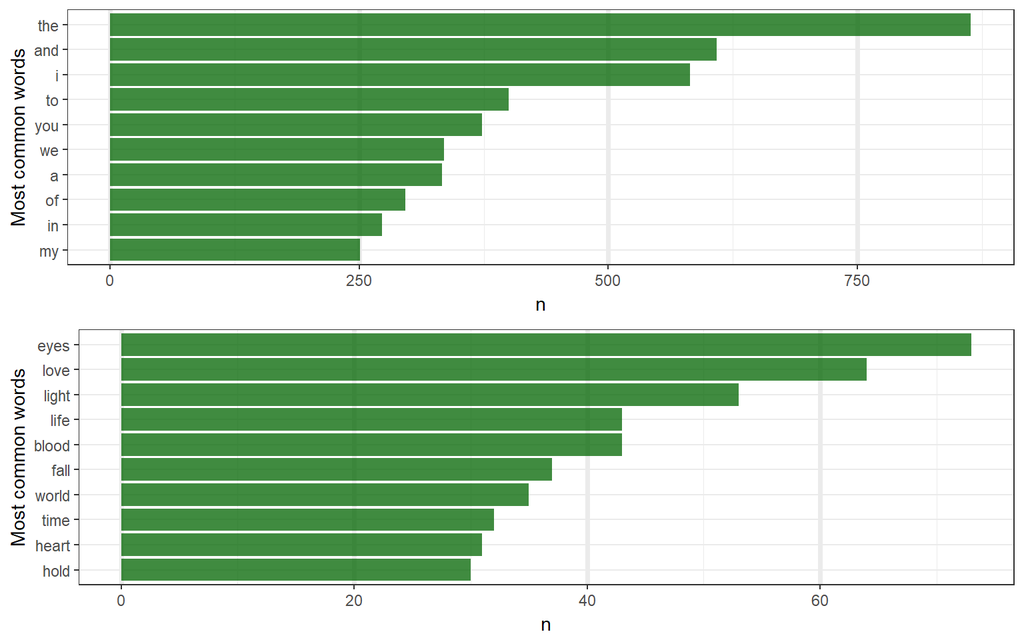

```r
# graph of top words (including stop words) ####
one <- countWord %>% head(10) %>%
  ggplot(aes(reorder(word, n), n)) +
  geom_bar(stat = "identity", fill = "darkgreen", alpha = 0.75) +
  xlab("Most common words") +
  coord_flip() +
  theme_bw() +
  theme(panel.grid.major.x = element_line(size = 1.25))

# graph of top words (no stop words) ####
two <- countWord2 %>% head(10) %>%
  ggplot(aes(reorder(word, n), n)) +
  geom_bar(stat = "identity", fill = "darkgreen", alpha = 0.75) +
  xlab("Most common words") +
  coord_flip() +
  theme_bw() +
  theme(panel.grid.major.x = element_line(size = 1.25))

grid.arrange(one, two)
```

You can clearly see the difference like this!

The fact that the scales for `n` are very different between the plot with “stop words” and the one without shows how individually meaningless “stop words” such as “the”, “and”, “to”, and “a” can really disrupt our analyses. The plot without “stop words” gives us a much clearer idea of the most meaningful and common words in Thrice’s lyrics!

One way to see this obscure>> disruption in action is by visualizing our data in a different way, using word clouds!

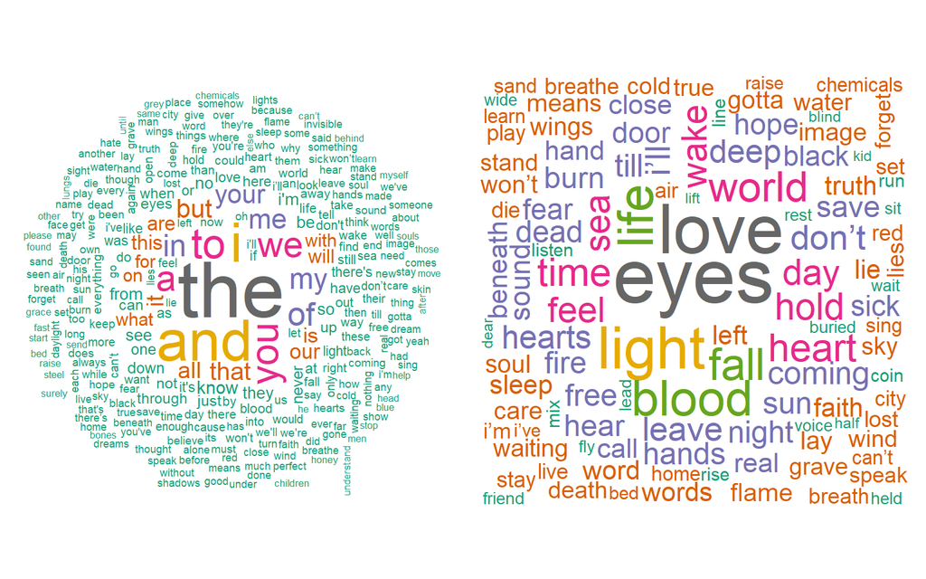

```r
# WORD CLOUD (comparison stop vs. no-stop)   ####
library(wordcloud)
layout(matrix(c(1,2),1,2, byrow = TRUE))

wordcloud(words = countWord$word, freq = countWord$n, random.order = FALSE, max.words = 300,
          colors = brewer.pal(8, "Dark2"), use.r.layout = TRUE)

# compare with wordcloud without stop_words!
wordcloud(countWord2$word, countWord2$n, random.order = FALSE, max.words = 300,
          colors = brewer.pal(8, "Dark2"), use.r.layout = TRUE)
```

With the word cloud visualization, we can really tell how the “stop words” in the left side obscures or “crowds out” all of the other more meaningful words due to the sheer amount of “the”s, “you”s, and “to”s that appear in the text.

Now that we’ve spread out each word into it’s own row, let’s take a closer look at our new datasets using our handy dplyr verbs!

```r
####    Explore dataset with dplyr verbs!   ####

df %>% summarise(num_songs = n()) # 103 songs in total, as each row = 1 song
```

```
##   num_songs
## 1       103
```

- several ways to do this as shown in Part 1 using n_distinct() on `title`…
- the `n()` function specifically counts the # of obsv in the current group and can only be
- used inside summarize(), mutate(), and filter()
- another example of n(), usage in conjunction with group_by()
- songs per album (by order of # of songs desc) >>> did this in part 1

```r
df %>% group_by(album) %>%
  summarise(num_songs = n()) %>%
  arrange(desc(num_songs))
```

```
## # A tibble: 11 x 2
##                                 album num_songs
##                                <fctr>     <int>
##  1             The Illusion Of Safety        13
##  2        The Artist In The Ambulance        12
##  3                    Identity Crisis        11
##  4                            Vheissu        11
##  5                        Major Minor        11
##  6 To Be Everywhere And To Be Nowhere        11
##  7                            Beggars        10
##  8             The Alchemy Index Fire         6
##  9            The Alchemy Index Water         6
## 10              The Alchemy Index Air         6
## 11            The Alchemy Index Earth         6
```

- words per song?

```r
df %>% group_by(title) %>%
  select(title, album, numWord) %>%
  arrange(desc(numWord))
```

```
## # A tibble: 103 x 3
## # Groups:   title [103]
##                          title                              album numWord
##                          <chr>                             <fctr>   <dbl>
##  1                  The Weight                            Beggars     421
##  2                 Black Honey To Be Everywhere And To Be Nowhere     410
##  3                     Wake Up To Be Everywhere And To Be Nowhere     342
##  4                Stay With Me To Be Everywhere And To Be Nowhere     326
##  5                   Under Par                    Identity Crisis     325
##  6          The Sky Is Falling              The Alchemy Index Air     321
##  7                The Arsonist             The Alchemy Index Fire     317
##  8           Blood On The Sand To Be Everywhere And To Be Nowhere     309
##  9                 Doublespeak                            Beggars     306
## 10 The Artist In The Ambulance        The Artist In The Ambulance     305
## # ... with 93 more rows
```

- The Weight has the most words, however the df dataset >>> (all incl. stop words)… also includes  
  though…
- need to use wordToken instead of df or wordToken2 as stop_words should be included for sum

```r
wordToken %>%
  select(title, word) %>%
  group_by(title) %>%
  summarize(num_word = n()) %>%
  arrange(desc(num_word))
```

```
## # A tibble: 100 x 2
##                          title num_word
##                          <chr>    <int>
##  1                  The Weight      383
##  2                 Black Honey      365
##  3                     Wake Up      297
##  4                   Under Par      293
##  5                Stay With Me      292
##  6                The Arsonist      284
##  7          The Sky Is Falling      281
##  8           Blood On The Sand      280
##  9 The Artist In The Ambulance      279
## 10                    Daedalus      273
## # ... with 90 more rows
```

More accurate measure of the total number of words per song! as counts each row which is divided into a single word from applying unnest_tokens() function to wordToken earlier!

How about words per album??

- instrumentals still count the blank as 1, but insignificant.

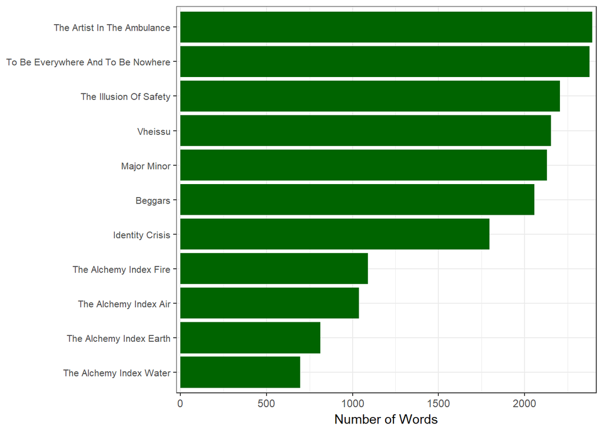

```r
# numWord by album
wordToken %>%
  select(album, word) %>%
  group_by(album) %>%
  summarize(num_word = n()) %>%
  arrange(desc(num_word)) %>%
  ggplot(aes(reorder(album, num_word), num_word)) +
  geom_bar(stat = "identity", fill = "darkgreen") +
  scale_y_continuous(expand = c(0.01, 0)) +
  coord_flip() +
  theme_bw() +
  theme(axis.text.y = element_text(size = 8), axis.title.y = element_blank()) +
  ylab("Number of Words")
```

- using count of “word” in unnested wordToken
- and original df “numWord” estimates similar enough…

```r
# random stuff
# use str_*() functions to find and dig deeper into specific words!

df %>%
  filter(album == "Vheissu") %>%
  select(numWord) %>%
  sum()
```

```
## [1] 2413
```

```r
sum(str_count(df$lyrics, "<br>"))   # 2562 breaks in total
```

```
## [1] 2562
```

```r
sum(str_count(df$lyrics, "light"))
```

```
## [1] 86
```

```r
wordToken$word[wordToken$word == "light"]
```

```
##  [1] "light" "light" "light" "light" "light" "light" "light" "light"
##  [9] "light" "light" "light" "light" "light" "light" "light" "light"
## [17] "light" "light" "light" "light" "light" "light" "light" "light"
## [25] "light" "light" "light" "light" "light" "light" "light" "light"
## [33] "light" "light" "light" "light" "light" "light" "light" "light"
## [41] "light" "light" "light" "light" "light" "light" "light" "light"
## [49] "light" "light" "light" "light" "light"
```

```r
# counting occurences of "light" in each song
# this looks through the "lyrics" column which as an entire song's lyrics inside and counts how many times "light" appears in the text
df %>%
  mutate(number = str_count(lyrics, pattern = "light")) %>%
  select(title, album, number) %>%
  arrange(desc(number)) %>%
  head(6)
```

```
##                              title                              album
## 1 Between The End And Where We Lie                            Vheissu
## 2      The Artist In The Ambulance        The Artist In The Ambulance
## 3                        Music Box                            Vheissu
## 4                       The Window To Be Everywhere And To Be Nowhere
## 5       A Torch To End All Torches                    Identity Crisis
## 6                        Under Par                    Identity Crisis
##   number
## 1     13
## 2      5
## 3      5
## 4      5
## 5      3
## 6      3
```

```r
wordToken2 %>%
  select(word) %>%
  str_count("light") %>%
  sum()
```

```
## [1] 87
```

```r
# total number of times "light" appears in lyrics of song, separated by each word or tokenized dataset ...(desc. order)

# counting occurences of "light" in each song
# count each specific appearance of "light" in "word" column
# then sum up occurences by song ("title")
wordToken2 %>%
  select(title, album, word) %>%
  mutate(light = str_count(word, "light")) %>%
  group_by(title) %>%
  summarize(total_light = sum(light)) %>%
  arrange(desc(total_light)) %>%
  head(5)
```

```
## # A tibble: 5 x 2
##                              title total_light
##                              <chr>       <int>
## 1 Between The End And Where We Lie          13
## 2                        Music Box           5
## 3      The Artist In The Ambulance           5
## 4                       The Window           5
## 5      A Song For Milly Michaelson           3
```

```r
df %>%
  filter(title == "The Weight") %>%
  select(album, title, numWord, numLines)
```

```
##     album      title numWord numLines
## 1 Beggars The Weight     421       38
```

```r
# 421
wordToken %>%
  filter(title == "The Weight") %>%
  summarize(num_word = n())    # count rows, in this case: one row = one word
```

```
##   num_word
## 1      383
```

```r
# 383
```

```r
# most frequent word in each song ####
wordToken2 %>%
  group_by(title) %>%
  count(word) %>%
  arrange(desc(n))
```

```
## # A tibble: 4,186 x 3
## # Groups:   title [100]
##                               title      word     n
##                               <chr>     <chr> <int>
##  1                      Black Honey      ill    20
##  2                          Wake Up     gotta    17
##  3                          Wake Up      wake    17
##  4                     Yellow Belly     dont    16
##  5                       The Weight     wont    15
##  6           Image Of The Invisible     image    13
##  7           Image Of The Invisible invisible    13
##  8          The Earth Isn't Humming      fall    13
##  9                Blood On The Sand      sick    12
## 10 Between The End And Where We Lie  daylight    11
## # ... with 4,176 more rows
```

- “I’ll” in Black Honey >>> song about
- “image” and “invisible” in “Image of the Invisible” >>> given as shouted out during the chorus numerous
- times in the song… To consider: skewed toward phrases repeated in chorus!

```r
# WordsPerNoStop
df %>%
  mutate(lyrics = str_replace_all(lyrics, '\'', ' ')) %>%
  unnest_tokens(line, lyrics, token = stringr::str_split, pattern = ' <br>') %>%
  unnest_tokens(word, line) %>%
  anti_join(stop_words) %>%           # filter stop words
  group_by(title) %>%
  summarize(wordcounts = n()) %>%
  arrange(desc(wordcounts))
```

```
## # A tibble: 100 x 2
##                               title wordcounts
##                               <chr>      <int>
##  1                       The Weight        120
##  2                      Doublespeak        116
##  3   A Living Dance Upon Dead Minds        112
##  4                      Black Honey        107
##  5                   Hold Fast Hope        107
##  6      The Artist In The Ambulance        106
##  7                 Stare At The Sun        103
##  8 Between The End And Where We Lie         99
##  9                          Wake Up         99
## 10        So Strange I Remember You         95
## # ... with 90 more rows
```

```r
# Distribution of Songs by # of Words
medianWord <- median(df$numWord)

one <- df %>%
  ggplot(., aes(x = numWord)) +
  geom_histogram(binwidth = 10,
                 color = 'white',
                 fill = 'darkgreen') +
  geom_vline(aes(xintercept = medianWord), colour = "red", linetype = "dashed", size = 1.25) +
  scale_y_continuous(breaks = pretty_breaks(), expand = c(0, 0), limits = c(0, 12)) +
  scale_x_continuous(breaks = pretty_breaks(), expand = c(0, 0)) +
  xlab('Total # of Words') +
  ylab('# of Songs') +
  labs(title = 'Distribution of Songs by Number of Words (Est. numWord measure)',
       subtitle = 'Dashed red line: median') +
  theme_bw() +
  theme(panel.grid.minor = element_blank(),
        plot.title = element_text(hjust = 0.5))
```

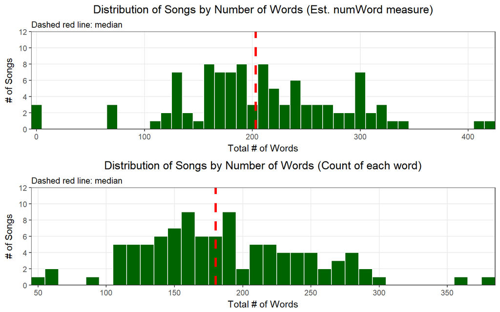

```r
# same as above^ but should be more accurate?

# WordsPerSong
WordsPerSong <- wordToken %>%   # NOT filter stop words (included in the lyrics for the total count)
  group_by(title) %>%
  summarize(wordcounts = n()) %>%    # each row = 1 word
  arrange(desc(wordcounts))

# Histogram of Word counts (per Song)   >>>> same as in uni-bi-tri section...
two <- WordsPerSong %>%
  ggplot(aes(x = wordcounts)) +
  geom_histogram(binwidth = 10, color = "white", fill = "darkgreen") +
  geom_vline(xintercept = median(WordsPerSong$wordcounts), color = "red", linetype = "dashed", size = 1.25) +
  scale_y_continuous(breaks = pretty_breaks(), expand = c(0, 0), limits = c(0, 12)) +
  scale_x_continuous(breaks = pretty_breaks(), expand = c(0, 0)) +
  xlab('Total # of Words') +
  ylab('# of Songs') +
  labs(title = 'Distribution of Songs by Number of Words (Count of each word)',
       subtitle = 'Dashed red line: median') +
  theme_bw() +
  theme(panel.grid.minor = element_blank(),
        plot.title = element_text(hjust = 0.5))

# compare accuracy of numWord method used...
grid.arrange(one, two)
```

```r
# crucial difference: WordsPerSong filter out instrumentals all together!
# df includes instrumentals and has counted as 1
```

```r
# most frequent unigrams per album: ####
# nested on albums!

word_count_nested <- wordToken2 %>%
  group_by(album, word) %>%
  summarize(count = n()) %>%
  top_n(10) %>%
  arrange(album, desc(count)) %>%
  nest()
```

```r
word_count_nested$data[[1]]
```

```
## # A tibble: 21 x 2
##     word count
##    <chr> <int>
##  1 heart    12
##  2  eyes     8
##  3  life     6
##  4 light     6
##  5   cry     5
##  6 faith     5
##  7  soul     5
##  8  true     5
##  9   day     4
## 10  deep     4
## # ... with 11 more rows
```

```r
word_count_nested$data[[5]]
```

```
## # A tibble: 13 x 2
##       word count
##      <chr> <int>
##  1    free    15
##  2    burn    13
##  3    send    11
##  4    fire    10
##  5   flame     9
##  6    city     7
##  7    eyes     7
##  8 breathe     5
##  9    door     5
## 10   leave     5
## 11    love     5
## 12    real     5
## 13    wait     5
```

```r
word_count_nested <- word_count_nested %>%
  mutate(plot = map2(data, album,
                     ~ggplot(data = .x) +
           geom_bar(aes(reorder(word, count), count),
                    stat = "identity", fill = "darkgreen", width = 0.65) +
           scale_y_continuous(breaks = pretty_breaks(10), limits = c(0, 22), expand = c(0, 0)) +
           ggtitle(.y) +
           labs(x = NULL, y = NULL) +
           coord_flip() +
           theme_bw() +
           theme(axis.text.y = element_text(size = 7),
                 title = element_text(size = 7))
           ))

glimpse(word_count_nested)
```

```
## Observations: 11
## Variables: 3
## $ album <fctr> Identity Crisis, The Illusion Of Safety, The Artist In ...
## $ data  <list> [<# A tibble: 21 x 2,     word count,    <chr> <int>,  ...
## $ plot  <list> [<heart, eyes, life, light, cry, faith, soul, true, day...
```

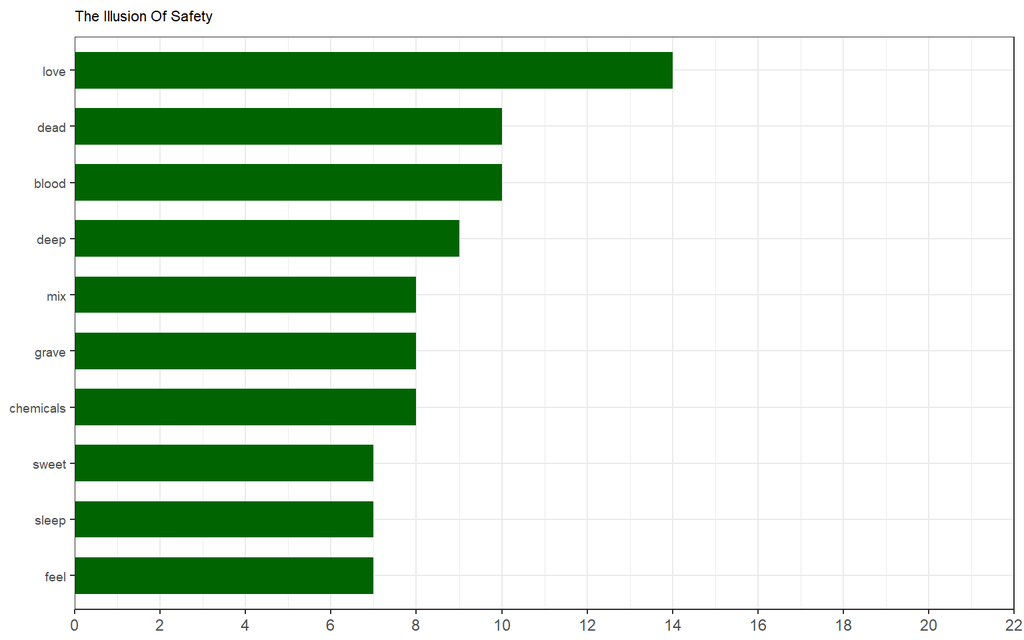

```r
word_count_nested$plot[[2]]
```

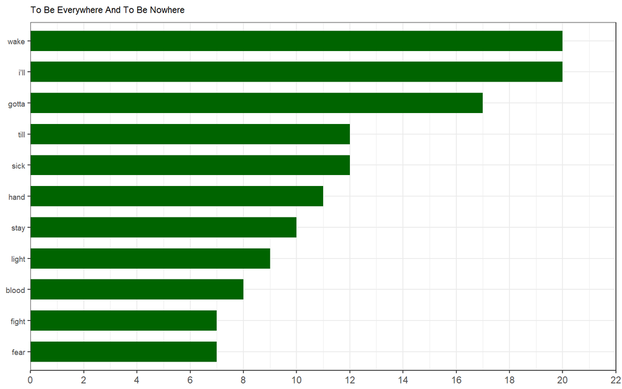

```r
word_count_nested$plot[[11]]
```

With everything organized in a “tidy” way, let’s try to plot for ALL of the albums!

First let’s try with something we used in Part 1, facetting!

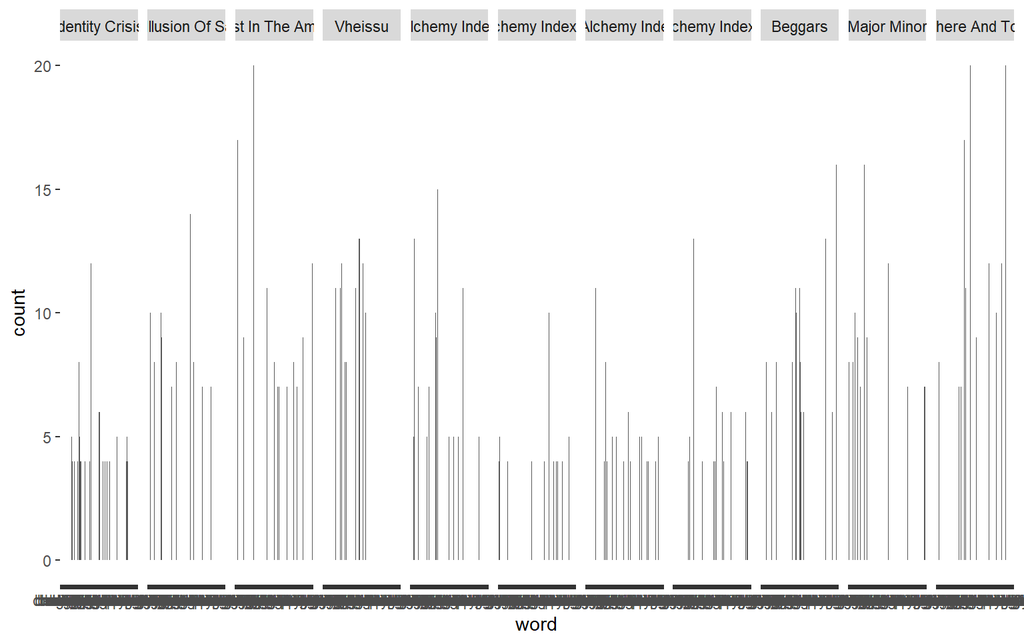

```r
word_count_nested %>%
  unnest(data) %>%                   # take data out from list
  ggplot(aes(x = word, y = count)) +
  geom_bar(stat = "identity") +
  facet_grid(.~album)
```

- can see that this won’t work with facetting as we face the problem of there not being enough space for all the albums to fit in a single row.
- even then data will be hard to compare side-by-side.
- if facetting done the other way around with each album as a row stacked on top of another, still difficult to see the differences in the heights of the bar counts

What can we do? One way to solve our problem is to code in a way that each plot for each album is printed out individually and then to arrange all those individual plots into one page. This will solve the problem with facetting this group of plots won’t be forcibly squished together into one gigantic plot. - save all plots in as one list

```r
nested_plots <- word_count_nested$plot[1:4]
```

[output not shown]

[output cut: 894 more lines]

[output not shown]

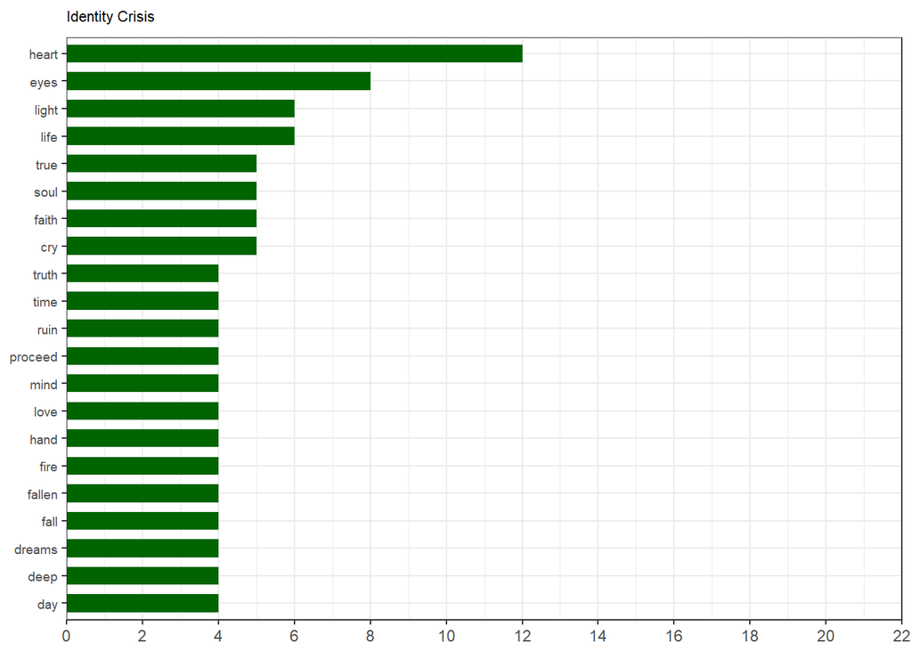

```r
glimpse(nested_plots)[[1]]
```

```r
str(nested_plots, list.len = 2, max.level = 2)
```

```
## List of 4
##  $ :List of 9
##   ..$ data       :Classes 'tbl_df', 'tbl' and 'data.frame':  21 obs. of  2 variables:
##   ..$ layers     :List of 1
##   .. [list output truncated]
##   ..- attr(*, "class")= chr [1:2] "gg" "ggplot"
##  $ :List of 9
##   ..$ data       :Classes 'tbl_df', 'tbl' and 'data.frame':  10 obs. of  2 variables:
##   ..$ layers     :List of 1
##   .. [list output truncated]
##   ..- attr(*, "class")= chr [1:2] "gg" "ggplot"
##   [list output truncated]
```

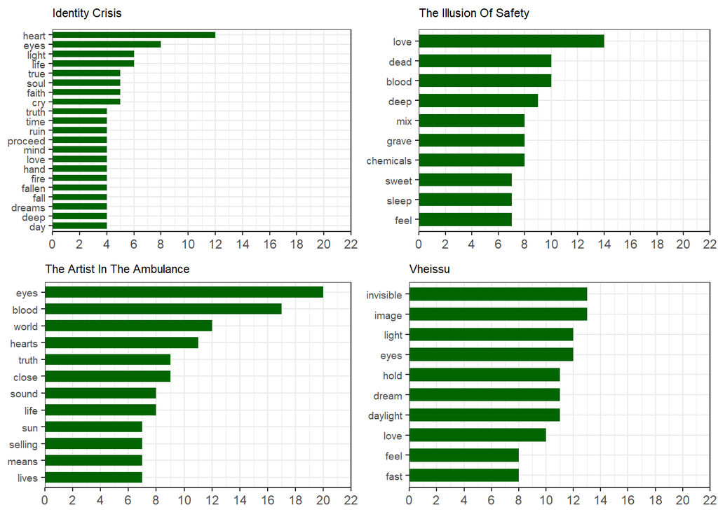

```r
do.call(grid.arrange, c(nested_plots, ncol = 2))
```

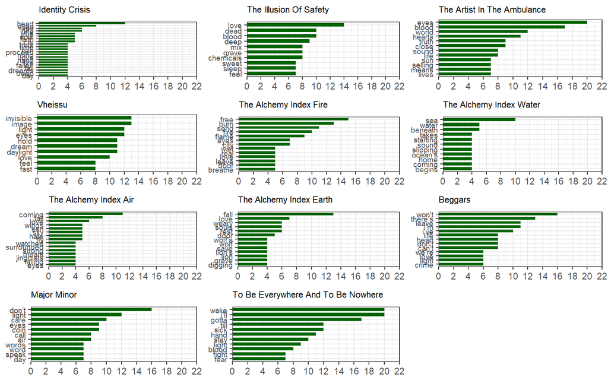

```r
# base R method with do.call() function:
do.call(grid.arrange, c(word_count_nested$plot, ncol = 3))
```

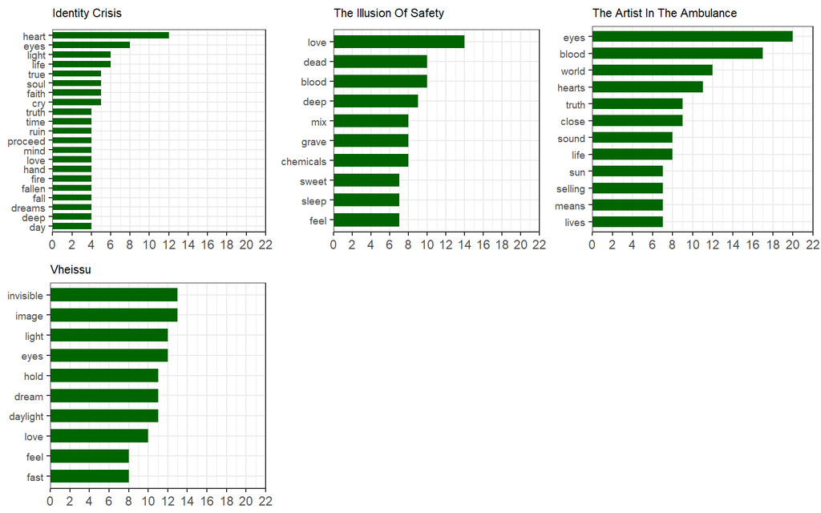

```r
# works very easily with cowplot::plot_grid() function!
# call list of ggplots (per album) with plotlist = __ then specify # of columns/rows/etc...
library(cowplot)
plot_grid(plotlist = nested_plots, ncol = 3)
```

```r
# save plot of most frequent word (for each album) individually now! ####
# apply the function ggsave() so that it iteratively saves the plot for each album!
map2(paste0(word_count_nested$album, ".pdf"), word_count_nested$plot, ggsave)
```

## In Part 3 we will look more closely at the different sentiments of the words in Thrice’s lyrics!